```python
import pandas as pd
import os
import matplotlib.pyplot as plot
```

```python
path = "C:/Users/lraul/Desktop"
file = "labdistribucion/datosincompletos2020perfiles.csv"
pathdata = os.path.join(path,file)
```

# NUMERAL 1

se modifico la base de datos original 1) Se le presenta un CSV que contiene 25 datos, en este CSV los datos son: profesión, ingresos de ese profesional y el sexo [Yes o 1 para Masculino y No o 0 para Femenino]. Debe crear un archivo CSV completo fusionando el archivo original con el nuevo creado. El archivo creado con números aleatorios debe contener los siguientes datos.

a) Edad (su rango debe ir entre los 20 a 40 años (con desviación están de 4 años).

b) Años de experiencia como mínimo 2 como máximo 20.

c) Años de estudio (tome en cuenta que como mínimo tienen técnico y máximo maestría ).

```python
#Lectura CSV
data = pd.read_csv(pathdata)
#Impresion del CSV
data
```

|  | profesión | ingresos | Sexo | edad | annos experiencia | annos estudio |
| --- | --- | --- | --- | --- | --- | --- |
| 0 | maestro | 3500.70 | Yes | 20 | 3 | 5 |
| 1 | programador | 7000.25 | Yes | 23 | 4 | 8 |
| 2 | diseñador | 4500.25 | Yes | 24 | 2 | 3 |
| 3 | maestro | 3700.50 | Yes | 25 | 1 | 3 |
| 4 | maestro | 4000.75 | Yes | 26 | 4 | 5 |
| 5 | programador | 9800.80 | Yes | 21 | 2 | 8 |
| 6 | arquitecto | 4500.01 | Yes | 22 | 4 | 5 |
| 7 | medico | 10000.35 | Yes | 34 | 1 | 3 |
| 8 | enfermera | 6250.20 | No | 35 | 1 | 3 |
| 9 | editor de videos | 3500.20 | No | 23 | 2 | 3 |
| 10 | asesor empresarial | 8900.21 | Yes | 27 | 3 | 5 |
| 11 | ingeniero civil | 6890.35 | No | 33 | 7 | 7 |
| 12 | quimico | 8504.02 | Yes | 35 | 4 | 5 |
| 13 | maestro | 6550.20 | Yes | 37 | 2 | 5 |
| 14 | maestra | 4870.20 | No | 25 | 3 | 5 |
| 15 | diseñadora | 7805.22 | No | 20 | 5 | 5 |
| 16 | medico | 12250.05 | Yes | 22 | 2 | 5 |
| 17 | abogado | 9000.27 | Yes | 32 | 2 | 3 |
| 18 | abogada | 5580.25 | No | 23 | 2 | 5 |
| 19 | periodista | 5458.23 | Yes | 20 | 3 | 7 |
| 20 | periodista | 8577.40 | No | 26 | 3 | 5 |
| 21 | diseñadora | 7898.20 | No | 32 | 2 | 7 |
| 22 | enfermero | 6890.22 | Yes | 28 | 1 | 3 |
| 23 | medico | 11257.58 | Yes | 24 | 2 | 3 |
| 24 | comerciante | 8555.25 | Yes | 39 | 2 | 5 |

# NUMERAL 3

Estadistica de los datos

```python
datos1=data[["profesión","ingresos","Sexo","edad","annos experiencia","ingresos"]]
df1=pd.DataFrame(datos1)
df1.describe()
```

|  | ingresos | edad | annos experiencia | ingresos |
| --- | --- | --- | --- | --- |
| count | 25.000000 | 25.000000 | 25.00000 | 25.000000 |
| mean | 7029.666400 | 27.040000 | 2.68000 | 7029.666400 |
| std | 2460.882888 | 5.834381 | 1.40594 | 2460.882888 |
| min | 3500.200000 | 20.000000 | 1.00000 | 3500.200000 |
| 25% | 4870.200000 | 23.000000 | 2.00000 | 4870.200000 |
| 50% | 6890.350000 | 25.000000 | 2.00000 | 6890.350000 |
| 75% | 8577.400000 | 32.000000 | 3.00000 | 8577.400000 |
| max | 12250.050000 | 39.000000 | 7.00000 | 12250.050000 |

# NUMERAL 4

diagrama de dispersión para verificar sí la edad tiene influencia con los ingresos

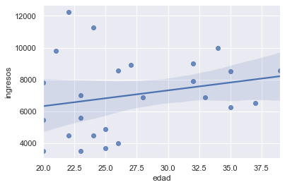

```python
import seaborn as sns
sns.set_theme(color_codes=True)
datos=data[["edad","ingresos"]]
df=pd.DataFrame(datos)

sns.regplot(x="edad", y="ingresos", data=df);
```

# -----------------------------------------------------------------------------------------

diagrama de dispersión para verificar sí los años de experiencia tienen influencia con los ingresos

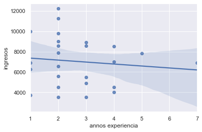

```python
import seaborn as sns
sns.set_theme(color_codes=True)

datos1=data[["annos experiencia","ingresos"]]
df1=pd.DataFrame(datos1)

sns.regplot(x="annos experiencia", y="ingresos", data=df1);
```